# **Normal Distribution Detailed Overview**

Arnab Aich

## Properties:

The **Normal Distribution** is a continuous probability distribution that is symmetric about its mean. It has the following key properties:

- **PDF**: The probability density function (PDF) of a normal distribution is given by:
  $$f(x |
  \mu, \sigma^2) = \frac{1}{\sigma \sqrt{2\pi}} e^{-\frac{(x -
  \mu)^2}{2\sigma^2}}$$
  where:
  - $\mu$ is the mean
  - $\sigma^2$ is the variance
  - $x$ is the variable of interest
- **Range**: The range of the normal distribution is from $-\infty$ to $+\infty$.
- **Parameters**: The two parameters that define a normal distribution are:
  - $\mu$ (mean): Determines the location of the center of the distribution
  - $\sigma$ (standard deviation): Determines the spread or dispersion of the distribution
- **Symmetry**: The normal distribution is symmetric around the mean, with 50% of the data falling below the mean and 50% above the mean.

## Tail Probabilities:

In normal distribution problems, we often calculate probabilities for values in the upper or lower tails. Let’s consider an example where we find the upper and lower tail probabilities. We will calculate the probabilities for the upper and lower tails of the standard normal distribution and plot them side by side.

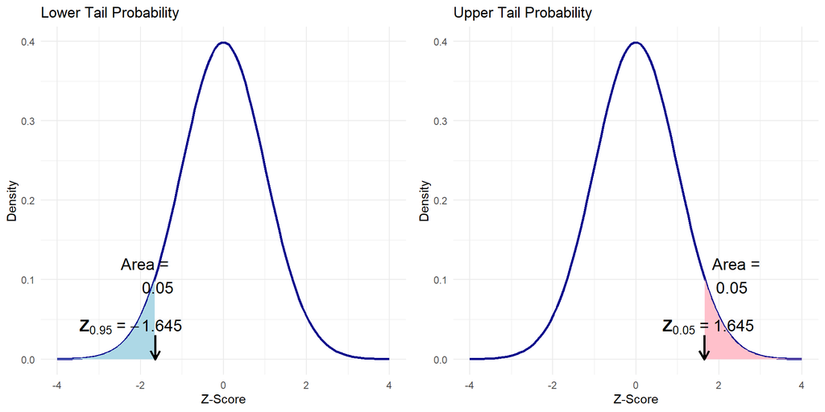

## Normal $(X)$ $\to$ Standard Normal $(Z)$:

Let’s assume the **monthly coffee consumption** of an individual follows a normal distribution with a mean of 10 liters and a standard deviation of 2 liters. This can be written as:

$$X \sim N(10, 2^2)$$

If **X** follows a normal distribution, then we can standardize the distribution using the Z-score transformation:

$$Z = \frac{X - \mu}{\sigma}$$

The standardized normal distribution is called the **Standard Normal Distribution** and has a mean of 0 and a standard deviation of 1. Standard normal probabilities are well-known and can be easily obtained from standard normal tables or software.

## Empirical Rule (68-95-99.7 Rule):

The empirical rule provides a quick way to understand the spread of data in a normal distribution: - 68% of data lies within 1 standard deviation of the mean - 95% of data lies within 2 standard deviations of the mean - 99.7% of data lies within 3 standard deviations of the mean

Let’s visualize this rule by drawing lines at ±1, ±2, and ±3 standard deviations from the mean on the curve, using different colors.

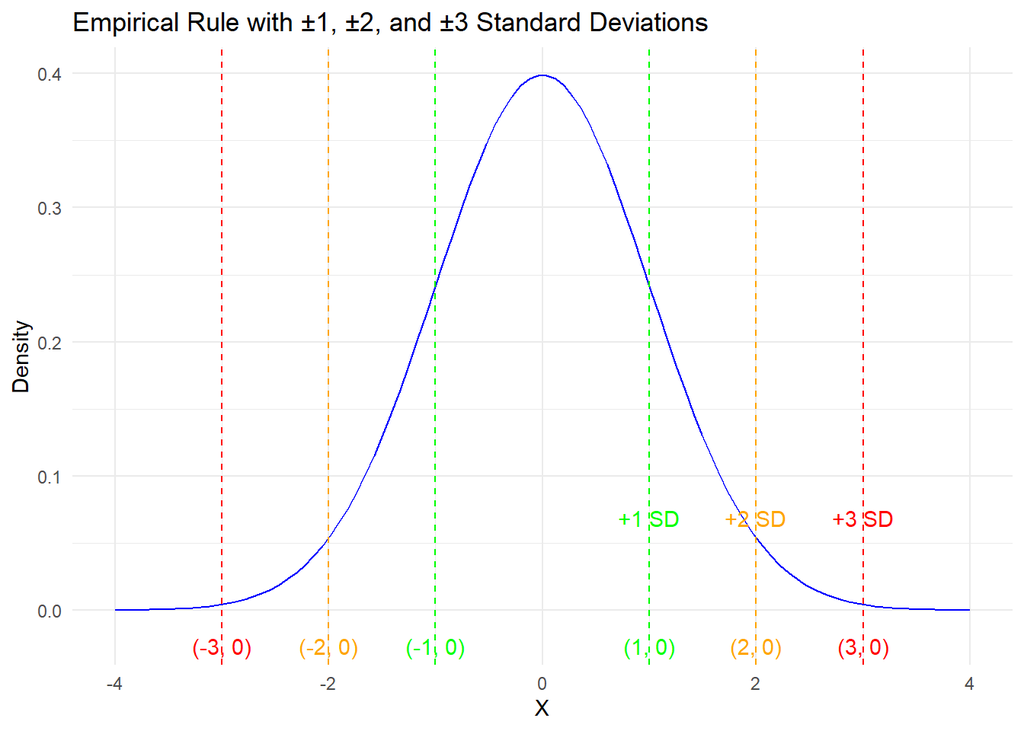

## Value to Probabilty (Monthly Coffee Consumption in Liters):

Consider the population monthly coffee consumption in liters follows a normal distribution with a mean of 10 liters and a standard deviation of 2 liters.

We can convert the value to a z-score and find the upper tail probability.

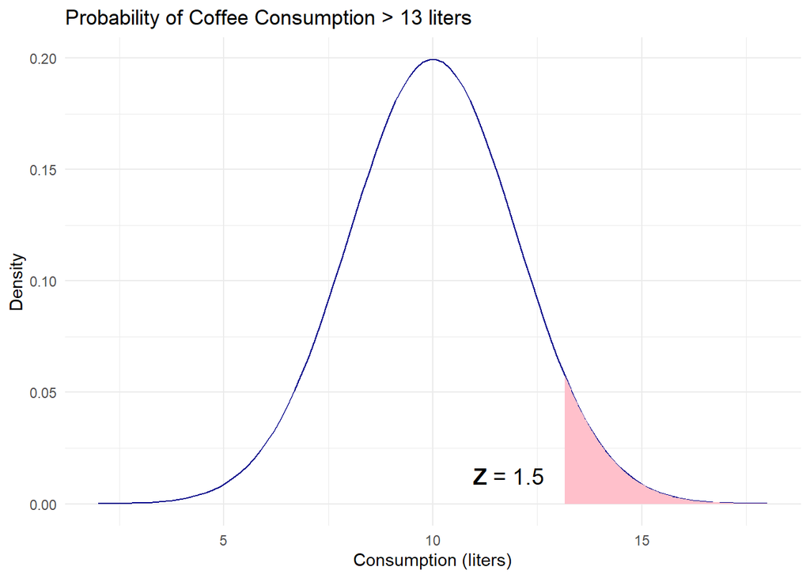

$$Z = \frac{13 - 10}{2} = 1.5$$

We can convert the value to a z-score and find the lower tail probability.

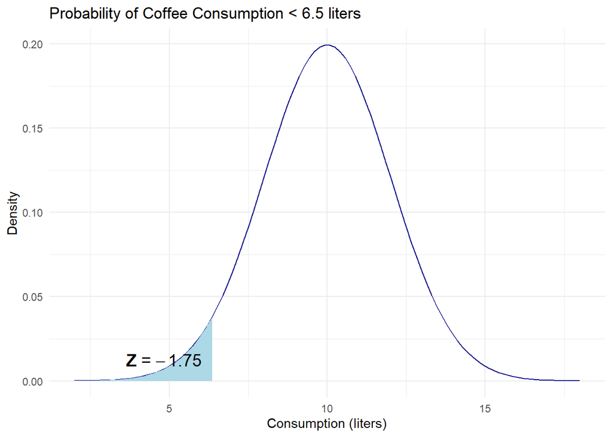

$$Z = \frac{6.5 - 10}{2} = -1.75$$

### What percentage of people drink between 9 and 12 liters of coffee per month?

This is the area between the two z-scores: $Z = -0.5$ and $Z = 1$.

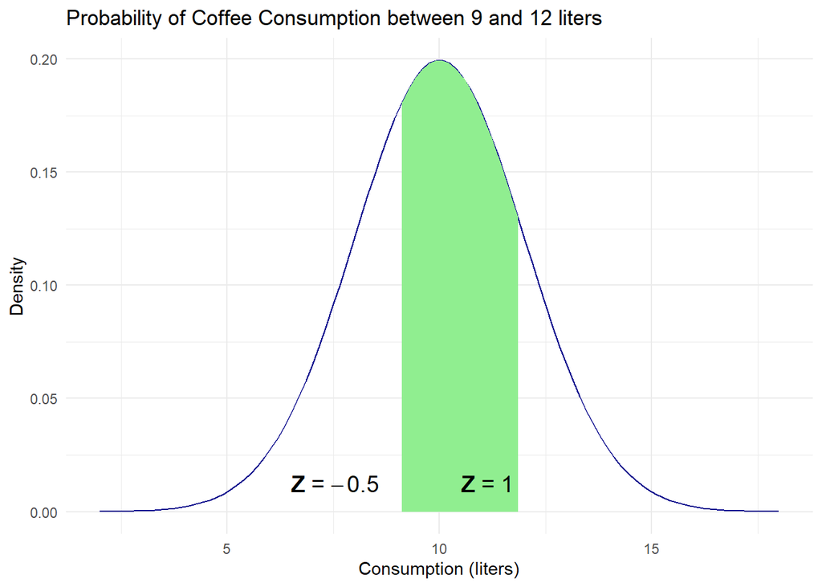

**Solution**: The area between $Z = -0.5$ and $Z = 1$ is approximately **54%** .

## Probabilty to Value (Daily Screen Time in Hours):

Consider the population daily screen time in hours follows a normal distribution with a mean of 6 hours and a standard deviation of 1.5 hours.

### Find the screen time that separates the top 10% of the population

Given that daily screen time follows a normal distribution with a mean of 6 hours and a standard deviation of 1.5 hours, we need to find the screen time value above which the top 10% of people spend on screens.

Explanation: - To find the screen time value that corresponds to the top 10%, we use the 90th percentile, as 10% of the population is in the upper tail. - The z-score corresponding to the 90th percentile from a standard normal distribution is approximately **1.28**. - We convert this z-score back to a screen time value using the formula:

$$X = \mu + Z \cdot \sigma$$

where $\mu$ is the mean (6 hours), $Z$ is the z-score (1.28), and $\sigma$ is the standard deviation (1.5 hours).

Calculation:

$$X = 6 + 1.28 \cdot 1.5 = 6 + 1.92 = 7.92 \text{hours}$$

Thus, the top 10% of people spend more than approximately **7.92 hours** per day on screens.

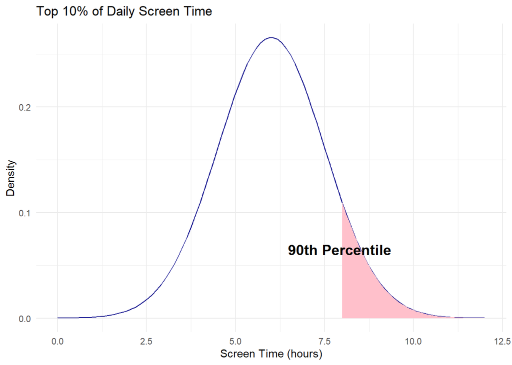

### Find the screen time that separates the bottom 25% of the population

We need to find the screen time value below which the bottom 25% of people spend on screens.

Explanation: - To find the screen time value that corresponds to the bottom 25%, we use the 25th percentile. - The z-score corresponding to the 25th percentile from a standard normal distribution is approximately **-0.674**. - We convert this z-score back to a screen time value using the formula:

$$X = \mu + Z \cdot \sigma$$

Calculation:

$$X = 6 + (-0.674) \cdot 1.5 = 6 - 1.011 = 4.99 \text{ hours}$$

Thus, the bottom 25% of people spend less than approximately **4.99 hours** per day on screens.

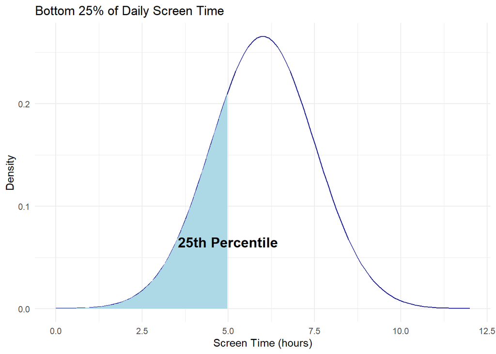

### What is the range of screen time for the middle 80% of the population?

We need to find the screen time values that correspond to the 10th and 90th percentiles, as the middle 80% is the range between these two percentiles.

Explanation: - The z-score for the **10th percentile** is approximately **-1.28**, and the z-score for the **90th percentile** is approximately **1.28**. - We convert these z-scores back to screen time values using the formula:

$$X = \mu + Z \cdot \sigma$$

#### Calculation for the 10th percentile:

$$X = 6 + (-1.28) \cdot 1.5 = 6 - 1.92 = 4.08 \text{ hours}$$

#### Calculation for the 90th percentile:

$$X = 6 + 1.28 \cdot 1.5 = 6 + 1.92 = 7.92 \text{ hours}$$

Thus, the middle 80% of people spend between approximately **4.08 hours** and **7.92 hours** per day on screens.

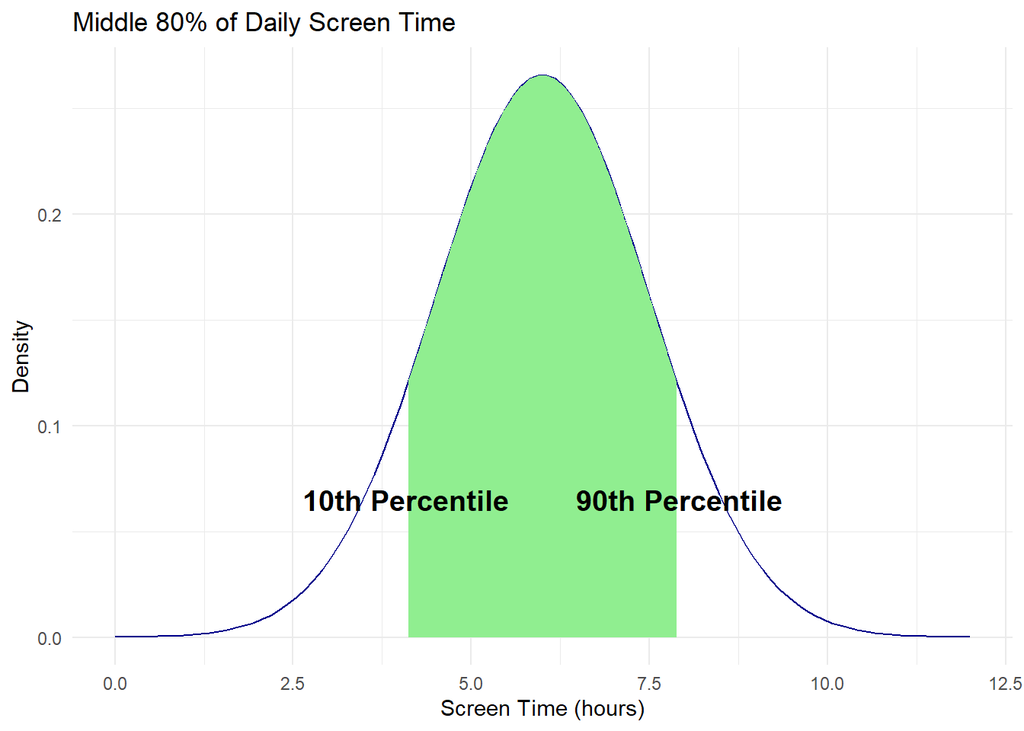

## Recap

The **Normal Distribution** is one of the most important probability distributions in statistics. It is a continuous distribution that is symmetric around its mean. Some key properties and concepts covered include:

- **Probability Density Function (PDF)**: The PDF of the normal distribution is given by:
  $$f(x | \mu, \sigma^2) = \frac{1}{\sigma \sqrt{2\pi}} e^{-\frac{(x -
  \mu)^2}{2\sigma^2}}$$
  where $\mu$ is the mean and $\sigma^2$ is the variance.
- **Z-score Transformation**: The Z-score standardizes a normal distribution, converting it to the standard normal distribution $Z \sim N(0, 1)$. The Z-score is calculated as:
  $$Z = \frac{X - \mu}{\sigma}$$
- **Empirical Rule** (68-95-99.7 Rule): The empirical rule describes how data is distributed in a normal distribution:
  - 68% of the data lies within 1 standard deviation of the mean.
  - 95% of the data lies within 2 standard deviations.
  - 99.7% of the data lies within 3 standard deviations.
- **Tail Probabilities**: Tail probabilities help us understand the likelihood of data falling into the extreme ends (tails) of the distribution. These are useful for finding areas under the curve beyond a certain Z-score.

## Q&A Section

### Question 1:

**What is the probability that a randomly selected value from a normal distribution is greater than 1.5 standard deviations from the mean?**

**Solution**: - First, calculate the Z-score:
$$Z = 1.5$$
- Using a standard normal table or calculator, find the probability for $Z > 1.5$:
$$P(Z > 1.5) \approx 0.0668$$
Thus, the probability is approximately **6.68%**.

### Question 2:

**What percentage of people have a height less than 160 cm, assuming heights follow a normal distribution with a mean of 170 cm and a standard deviation of 10 cm?**

**Solution**: - Find the Z-score:
$$Z = \frac{160 - 170}{10} = -1$$
- Using a standard normal table, find the probability for $Z < -1$:
$$P(Z < -1) \approx 0.1587$$
Thus, approximately **15.87%** of people have a height less than 160 cm.

### Question 3:

**Find the Z-score that corresponds to the top 5% of a standard normal distribution.**

**Solution**: - For the top 5%, you need the Z-score corresponding to the 95th percentile. Using the inverse normal function:
$$Z = 1.645$$
Thus, the Z-score is **1.645**.

### Question 4:

**If the daily screen time follows a normal distribution with a mean of 6 hours and a standard deviation of 1.5 hours, what percentage of people spend less than 4.5 hours per day on screens?**

**Solution**: - Find the Z-score:
$$Z = \frac{4.5 - 6}{1.5} = -1$$
- Using a standard normal table, find the probability for $Z < -1$:
$$P(Z < -1) = 0.1587$$
Thus, approximately **15.87%** of people spend less than 4.5 hours per day on screens.

### Question 5:

**What is the probability that a value is within 2 standard deviations of the mean in a normal distribution?**

**Solution**: - Using the empirical rule, we know that:
$$P(-2 < Z < 2) \approx 0.95$$
Thus, the probability is **95%**.

### Question 6:

**Given a normal distribution with a mean of 50 and a standard deviation of 5, find the probability that a randomly selected value is between 45 and 55.**

**Solution**: - First, calculate the Z-scores for 45 and 55:
$$Z_1 = \frac{45 - 50}{5} = -1, \quad Z_2 = \frac{55 - 50}{5} = 1$$
- Using a standard normal table:
$$P(-1 < Z < 1) \approx 0.6826$$
Thus, the probability is **68.26%**.

### Question 7:

**What Z-score corresponds to the 10th percentile in a standard normal distribution?**

**Solution**: - Using the inverse normal function, the Z-score for the 10th percentile is:
$$Z = -1.28$$
Thus, the Z-score is **-1.28**.

### Question 8:

**In a normal distribution with a mean of 100 and a standard deviation of 15, what is the probability of selecting a value between 85 and 115?**

**Solution**: - First, calculate the Z-scores for 85 and 115:
$$Z_1 = \frac{85 - 100}{15} = -1, \quad Z_2 = \frac{115 - 100}{15} = 1$$
- Using a standard normal table:
$$P(-1 < Z < 1) \approx 0.6826$$
Thus, the probability is **68.26%**.

### Question 9:

**Find the Z-score that separates the bottom 25% of a standard normal distribution.**

**Solution**: - For the 25th percentile, use the inverse normal function:
$$Z = -0.674$$
Thus, the Z-score is **-0.674**.

### Question 10:

**What percentage of data in a normal distribution falls within 1 standard deviation of the mean?**

**Solution**: - Using the empirical rule:
$$P(-1 < Z < 1) \approx 0.68$$
Thus, **68%** of data falls within 1 standard deviation of the mean.